# Compito 4/02/2019

Emanuele Lena - 142411@uniud

10/2/2022

```r
knitr::knit('Funzioni2.Rmd')
```

```
##
##
## processing file: Funzioni2.Rmd
```

[output not shown]

[output cut: 25 more lines]

[output not shown]

```
## output file: Funzioni2.md
```

```
## [1] "Funzioni2.md"
```

The aim of the study is to analyze the potential relationship between the response variable wage and the explanatory variables considered in the dataframe.

```r
wages <- read.table("./data/Wages-New.txt", header = TRUE)
wages$male <- factor(wages$male)
wages$region <- factor(wages$region)
summary(wages)
```

```
##      exper        male         school           wage              region
##  Min.   : 1.000   0:1569   Min.   : 3.00   Min.   :  0.07656   Center:1164
##  1st Qu.: 7.000   1:1727   1st Qu.:11.00   1st Qu.:  3.62673   North :1105
##  Median : 8.000            Median :12.00   Median :  5.20578   South :1027
##  Mean   : 8.042            Mean   :11.63   Mean   :  5.81639
##  3rd Qu.: 9.000            3rd Qu.:12.00   3rd Qu.:  7.30723
##  Max.   :18.000            Max.   :16.00   Max.   :112.79193
```

```
## [1] "SINTESI DI exper"
##    Min. 1st Qu.  Median    Mean 3rd Qu.    Max.    Var. StdDev.   Skew.   Kurt.
##  1.0000  7.0000  8.0000  8.0419  9.0000 18.0000  5.2480  2.2909  0.1556  3.6529
```

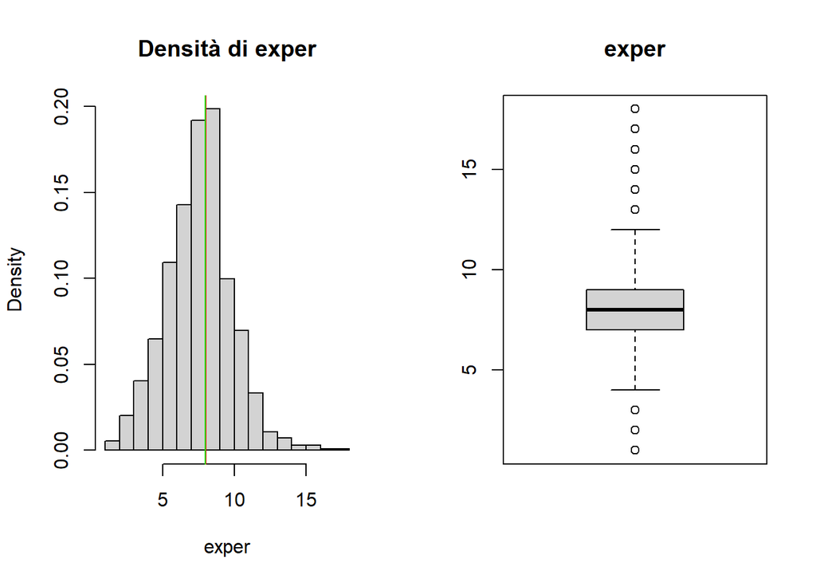

```
## [1] "SINTESI DI school"
##    Min. 1st Qu.  Median    Mean 3rd Qu.    Max.    Var. StdDev.   Skew.   Kurt.
##  3.0000 11.0000 12.0000 11.6302 12.0000 16.0000  2.7460  1.6571 -0.3935  4.2395
```

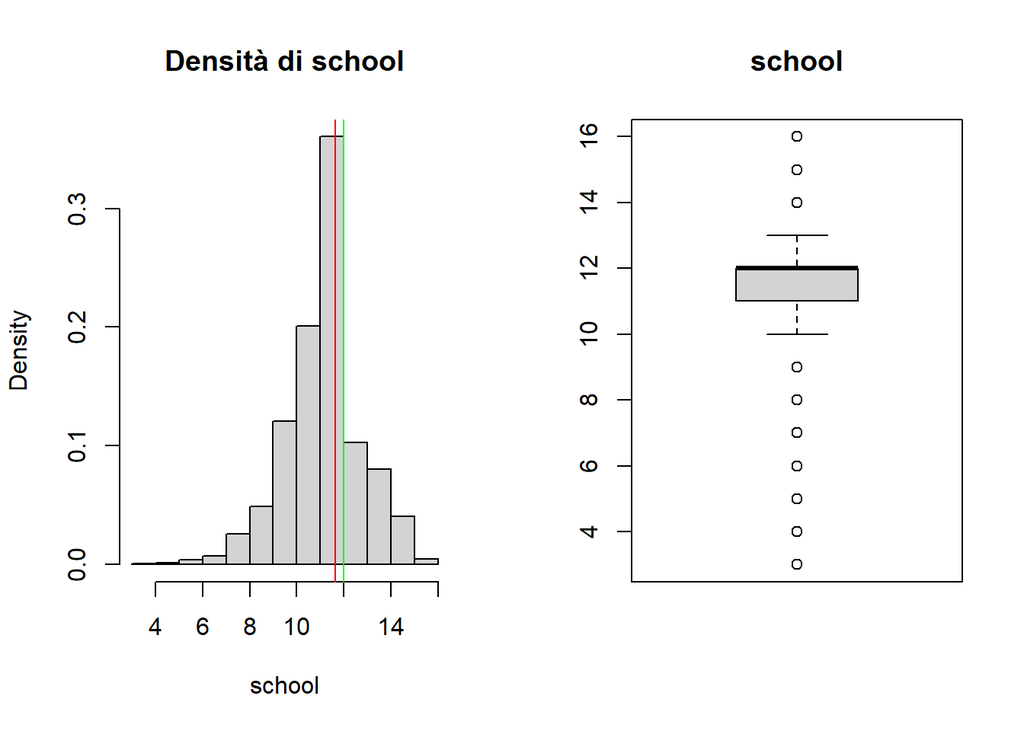

```r
par(mfrow=c(1,2))
for (v in c("exper", "school")) {
  gsummary.num(v, data=wages, smoothCurve = F, stats = T)
}
```

```r
par(mfrow=c(1,1))
```

exper e school sono due variabili numeriche intere. Le loro distribuzioni di probabilità sono riconducibili a campane più o meno normali. Esper risulta piuttosto simmetrica e le sue code risultano in linea con quelle di una distribuzione normale (dall’indice).

school soffre di una leggera assimmetria sinistra (evidente sia dall’istogramma, che dal boxplot e dall’indice di assim.) e presenta code più pesanti. Entrambi le funzioni presentano numerosi valori etichettati come outlyer

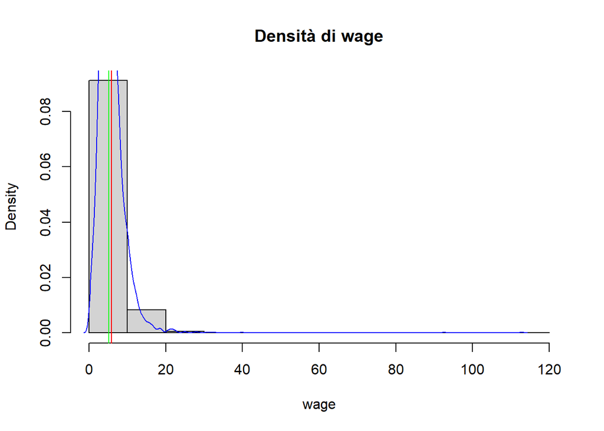

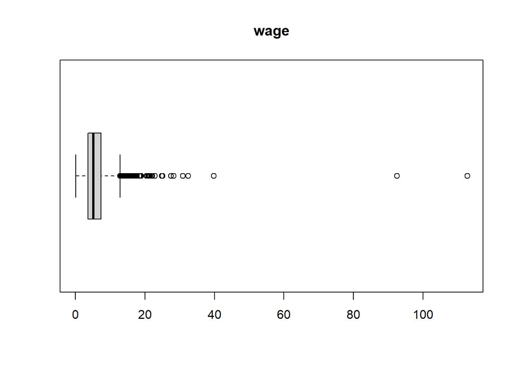

```r
par(mfrow=c(1,1))

gsummary.num("wage", data=wages, stats = F, horizontalBoxplot = T)
```

```r
par(mfrow=c(1,1))

summary.num("wage", data=wages, calcIndexes = F)
```

```
##      Min.   1st Qu.    Median      Mean   3rd Qu.      Max.      Var.   StdDev.
##   0.07656   3.62673   5.20578   5.81639   7.30723 112.79193  16.44054   4.05469
```

La variabile risposta wage è una variabile numerica continua. La sua curva di densità risulta fortemente concentrata a sinistra, con numerose osservazioni anche molto estreme. Tale tipo di variabile, probabilmente potrebbe risultare più “normale” se considerata in scala logaritmica.

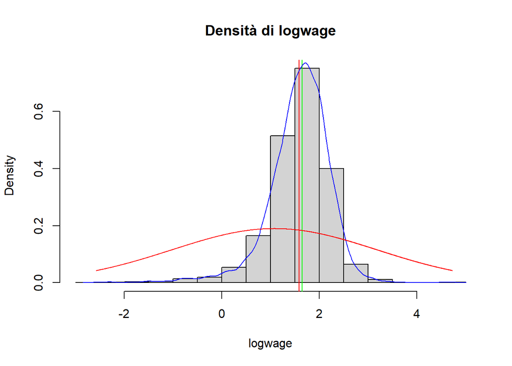

[figure not shown]

```r
wages2 <- wages
wages2$logwage <- log(wages$wage)

# par(mfrow=c(1,2))

gsummary.num("logwage", data=wages2, stats = F, horizontalBoxplot = T, normCurve = T)
```

```r
gsummary.norm("logwage", data=wages2, stats = T, statsTest = T)
```

```
## [1] "NORMALITA' DI logwage"
##       Mean       Var.      Skew.      Kurt.
##  1.5891125  0.3931602 -1.1184400  7.2836901
##
## Title:
##  D'Agostino Normality Test
##
## Test Results:
##   STATISTIC:
##     Chi2 | Omnibus: 788.4181
##     Z3  | Skewness: -21.5081
##     Z4  | Kurtosis: 18.0505
##   P VALUE:
##     Omnibus  Test: < 2.2e-16
##     Skewness Test: < 2.2e-16
##     Kurtosis Test: < 2.2e-16
##
## Description:
##  Thu Feb 10 18:38:33 2022 by user: Proprietario
```

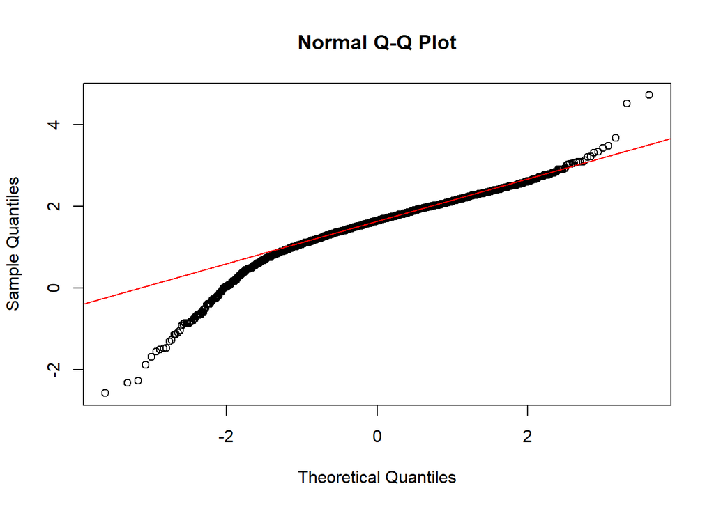

```r
# par(mfrow=c(1,1))
```

Anche riportando la var in scala logaritmica si ottiene una campana non normale. Innanzitutto si osserva una campana piuttosto stretta (rispetto a quella attesa). Questa volta, si osserva un’assimmetria sinistra e delle code classificate come pesanti dall’indice di curtosi.

In ongi caso, questa trasformazione è certamente un miglioramento.

```r
par(mfrow=c(2,2))

gsummary.factor("region", data=wages, stats = T,
                pieLabels = T, plots = c("rel", "pie"))
```

```
## [1] "SINTESI DI region"
##              Center        North        South
## F.Abs. 1164.0000000 1105.0000000 1027.0000000
## F.Rel.    0.3531553    0.3352549    0.3115898
```

```
## [1] "SINTESI DI male"
##                   0            1
## F.Abs. 1569.0000000 1727.0000000
## F.Rel.    0.4760316    0.5239684
```

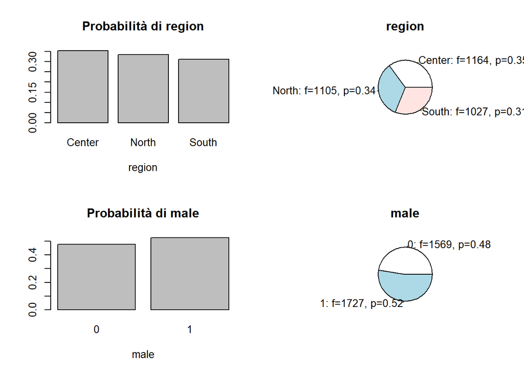

```r
gsummary.factor("male", data=wages, stats = T,
                pieLabels = T, plots = c("rel", "pie"))
```

```r
par(mfrow=c(1,1))
```

Infine, le categoriali categoriali region e male sembrano essere abbastanza uniformamente distribuite.

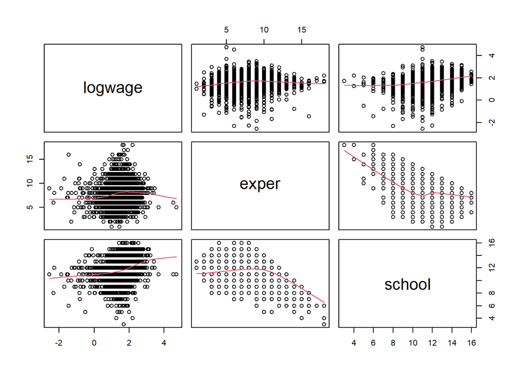

```r
pairs(wages2[c("logwage", "exper", "school")], panel=panel.smooth)
```

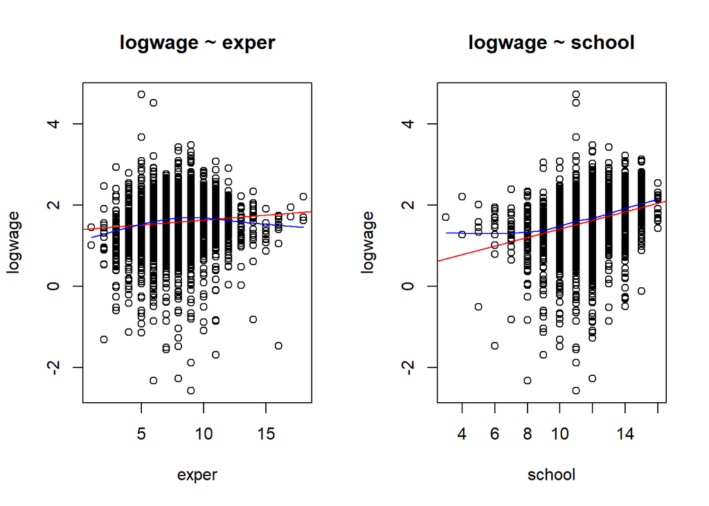

```r
par(mfrow=c(1,2))

cor.check.num(x="exper", y="logwage", data=wages2, doPlot = T, stats = F)
cor.check.num(x="school", y="logwage", data=wages2, doPlot = T, stats = F)
```

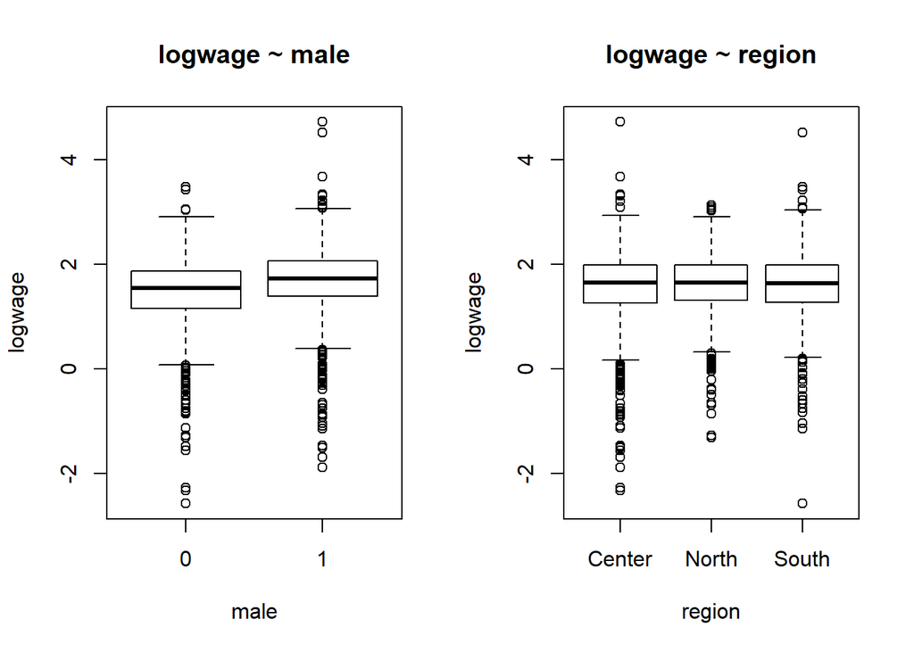

```r
cor.check.factor.num(xfactor = "male", y="logwage", data=wages2, stats = F)
cor.check.factor.num(xfactor = "region", y="logwage", data=wages2, stats = F)
```

```r
par(mfrow=c(1,1))
```

Dai grafici, non sembra trasparire alcuna correlazione particolarmente significativa tra logwage e le diverse variabili.

Le relazioni con school ed exper sembrano essere molto deboli e non lineari (i dati sono parecchio variabili) e region sembra essere totalmente ininfluente (se non fosse che per un certo livello si osserva maggiore variabilità).

```r
t.test.between.groups("male", "logwage", data=wages2)
```

```
## $`<0,1>`
##
##  Welch Two Sample t-test
##
## data:  data[data[[groupname]] == lvls[i], varname] and data[data[[groupname]] == lvls[j], varname]
## t = -10.113, df = 3233.3, p-value < 2.2e-16
## alternative hypothesis: true difference in means is not equal to 0
## 95 percent confidence interval:
##  -0.2605748 -0.1759458
## sample estimates:
## mean of x mean of y
##  1.474751  1.693011
```

Da un confronto sulle medie per gruppo, il fattore male sembra essere significativo.

Si calcolano gli indici di pearson e spearman come metriche per la significatività delle variabili numeriche:

```r
cor(wages2[c("logwage", "school", "exper")], method = "pearson")
```

```
##            logwage     school       exper
## logwage 1.00000000  0.2768363  0.08793084
## school  0.27683631  1.0000000 -0.19322539
## exper   0.08793084 -0.1932254  1.00000000
```

```r
cor(wages2[c("logwage", "school", "exper")], method = "spearman")
```

```
##            logwage      school       exper
## logwage 1.00000000  0.29563491  0.08672985
## school  0.29563491  1.00000000 -0.07042002
## exper   0.08672985 -0.07042002  1.00000000
```

Da tali coefficenti school sembra essere il parametro più significativo.

Procediamo definendo un modello di regressione lineare completo:

```r
wages2.lm <- lm(logwage~exper+school+male+region, data=wages2)
summary(wages2.lm)
```

```
##
## Call:
## lm(formula = logwage ~ exper + school + male + region, data = wages2)
##
## Residuals:
##     Min      1Q  Median      3Q     Max
## -4.0008 -0.2821  0.0468  0.3673  3.2337
##
## Coefficients:
##              Estimate Std. Error t value Pr(>|t|)
## (Intercept) -0.279709   0.090321  -3.097  0.00197 **
## exper        0.034618   0.004549   7.610 3.55e-14 ***
## school       0.122909   0.006278  19.578  < 2e-16 ***
## male1        0.246474   0.020607  11.961  < 2e-16 ***
## regionNorth  0.051107   0.024505   2.086  0.03709 *
## regionSouth  0.047168   0.024969   1.889  0.05898 .
## ---
## Signif. codes:  0 '***' 0.001 '**' 0.01 '*' 0.05 '.' 0.1 ' ' 1
##
## Residual standard error: 0.5831 on 3290 degrees of freedom
## Multiple R-squared:  0.1364, Adjusted R-squared:  0.1351
## F-statistic: 103.9 on 5 and 3290 DF,  p-value: < 2.2e-16
```

Dai test t sui regressori: exper, school e male=1 risultano tutti fattori rilevanti di effetto positivo sul modello. Non c’è invece altrettanto sostegno a fronte dell’utilità del fattore region.

La varianza spiegata, come previsto, è abbastanza bassa (i dati risultano parecchio variabili).

Il modello, in generale, dal test F risulta significativo rispetto al modello nullo.

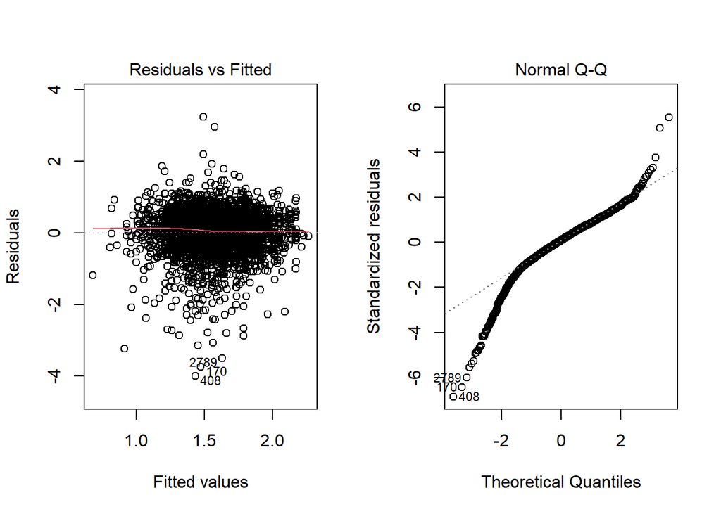

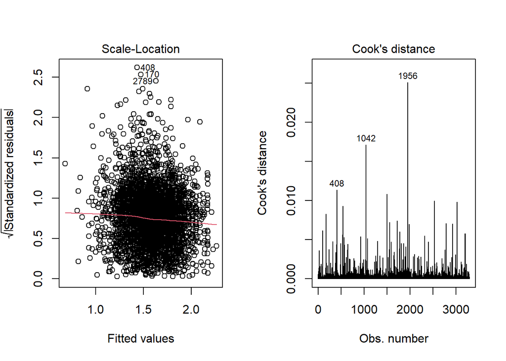

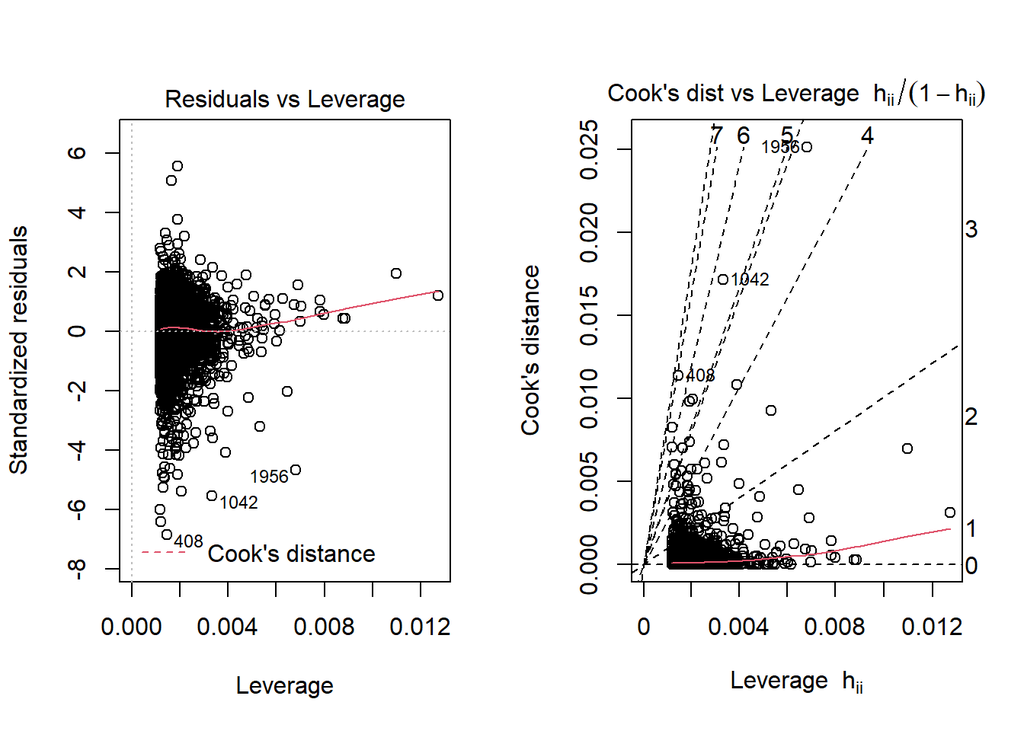

```r
par(mfrow=c(1,2))
plot(wages2.lm, which = (1:6))
```

```r
par(mfrow=c(1,1))
```

Dalle diagnostiche:

- non si osservano pattern strani sui residui
- la variabilità dei residui risulta uniforme
- nessun punto risulta avere un influenza particolarmente elevata in senso assoluto.

```r
anova(wages2.lm)
```

```
## Analysis of Variance Table
##
## Response: logwage
##             Df  Sum Sq Mean Sq  F value    Pr(>F)
## exper        1   10.02  10.016  29.4559 6.135e-08 ***
## school       1  116.18 116.180 341.6629 < 2.2e-16 ***
## male         1   48.69  48.691 143.1909 < 2.2e-16 ***
## region       2    1.83   0.915   2.6906   0.06799 .
## Residuals 3290 1118.74   0.340
## ---
## Signif. codes:  0 '***' 0.001 '**' 0.01 '*' 0.05 '.' 0.1 ' ' 1
```

Anche da un test anova, si conferma bassa significatività di region. Per tale motivo, si sperimenta la sua rimozione dal modello.

```r
wages2.lm2 <- lm(logwage~exper+school+male, data=wages2)
summary(wages2.lm2)
```

```
##
## Call:
## lm(formula = logwage ~ exper + school + male, data = wages2)
##
## Residuals:
##     Min      1Q  Median      3Q     Max
## -3.9852 -0.2832  0.0483  0.3658  3.2008
##
## Coefficients:
##              Estimate Std. Error t value Pr(>|t|)
## (Intercept) -0.243865   0.089033  -2.739   0.0062 **
## exper        0.034303   0.004549   7.541    6e-14 ***
## school       0.122778   0.006281  19.548   <2e-16 ***
## male1        0.246574   0.020616  11.960   <2e-16 ***
## ---
## Signif. codes:  0 '***' 0.001 '**' 0.01 '*' 0.05 '.' 0.1 ' ' 1
##
## Residual standard error: 0.5834 on 3292 degrees of freedom
## Multiple R-squared:  0.135,  Adjusted R-squared:  0.1342
## F-statistic: 171.3 on 3 and 3292 DF,  p-value: < 2.2e-16
```

```r
AIC(wages2.lm, wages2.lm2)
```

```
##            df      AIC
## wages2.lm   7 5806.308
## wages2.lm2  5 5807.694
```

```r
BIC(wages2.lm, wages2.lm2)
```

```
##            df      BIC
## wages2.lm   7 5849.011
## wages2.lm2  5 5838.197
```

Rimuovendo region dal modello però si osserva un leggero peggioramento nell’indice di determinazione (sia normale che corretto) e nell’AIC. Il BIC invece vede un leggero miglioramento.

Si prosegue indagando su eventuali effetti iterazione, confusione e collinearità.

In particolare:

- si vuole studiare la relazione tra il fattore male e gli altri regressori
- si vuole studiare eventuali effetti combinati interessanti su expr e school.

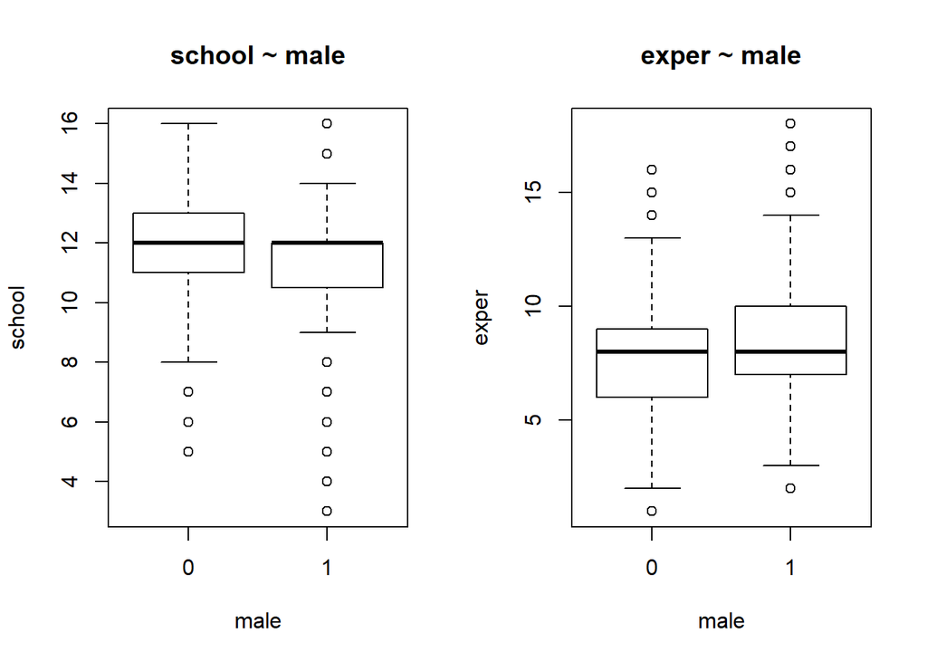

```r
# pairs(wages2[c("logwage", "exper", "school")], col=wages2$male)

par(mfrow=c(1,2))

cor.check.factor.num(xfactor = "male", y="school", data=wages2)
cor.check.factor.num(xfactor = "male", y="exper", data=wages2)
```

```r
par(mfrow=c(1,1))

summary.lm(aov(school~male, data=wages2))
```

```
##
## Call:
## aov(formula = school ~ male, data = wages2)
##
## Residuals:
##     Min      1Q  Median      3Q     Max
## -8.4418 -0.8375  0.1625  0.5582  4.5582
##
## Coefficients:
##             Estimate Std. Error t value Pr(>|t|)
## (Intercept) 11.83748    0.04154 284.946  < 2e-16 ***
## male1       -0.39567    0.05739  -6.894 6.46e-12 ***
## ---
## Signif. codes:  0 '***' 0.001 '**' 0.01 '*' 0.05 '.' 0.1 ' ' 1
##
## Residual standard error: 1.646 on 3294 degrees of freedom
## Multiple R-squared:  0.01422,    Adjusted R-squared:  0.01393
## F-statistic: 47.53 on 1 and 3294 DF,  p-value: 6.461e-12
```

```r
summary.lm(aov(exper~male, data=wages2))
```

```
##
## Call:
## aov(formula = exper ~ male, data = wages2)
##
## Residuals:
##     Min      1Q  Median      3Q     Max
## -6.7323 -1.3231  0.2677  1.2677  9.6769
##
## Coefficients:
##             Estimate Std. Error t value Pr(>|t|)
## (Intercept)  7.73231    0.05736 134.800  < 2e-16 ***
## male1        0.59079    0.07924   7.455 1.14e-13 ***
## ---
## Signif. codes:  0 '***' 0.001 '**' 0.01 '*' 0.05 '.' 0.1 ' ' 1
##
## Residual standard error: 2.272 on 3294 degrees of freedom
## Multiple R-squared:  0.01659,    Adjusted R-squared:  0.0163
## F-statistic: 55.58 on 1 and 3294 DF,  p-value: 1.14e-13
```

Si osserva che le osservazioni del gruppo male=1, tendenzialmente sembrano avere valori più bassi per school e valori più alti per exper.

La seconda correlazione potrebbe essere indice di effetto confusione (i maschi sembrano guadagnare di più visto che hanno più esperienza), detto ciò anche la relazione con school è curiosa.

Proviamo a sperimentare che succede considerando l’iterazione tra school e male e tra exper e male:

```r
wages2.lm3 <- lm(logwage~school*male+exper*male, data=wages2)
summary(wages2.lm3)
```

```
##
## Call:
## lm(formula = logwage ~ school * male + exper * male, data = wages2)
##
## Residuals:
##     Min      1Q  Median      3Q     Max
## -3.9928 -0.2862  0.0473  0.3642  3.1797
##
## Coefficients:
##               Estimate Std. Error t value Pr(>|t|)
## (Intercept)  -0.316879   0.128573  -2.465   0.0138 *
## school        0.124343   0.009587  12.970  < 2e-16 ***
## male1         0.402651   0.177003   2.275   0.0230 *
## exper         0.041349   0.006796   6.084  1.3e-09 ***
## school:male1 -0.004490   0.012750  -0.352   0.7248
## male1:exper  -0.013006   0.009189  -1.415   0.1571
## ---
## Signif. codes:  0 '***' 0.001 '**' 0.01 '*' 0.05 '.' 0.1 ' ' 1
##
## Residual standard error: 0.5834 on 3290 degrees of freedom
## Multiple R-squared:  0.1355, Adjusted R-squared:  0.1342
## F-statistic: 103.2 on 5 and 3290 DF,  p-value: < 2.2e-16
```

Si osserva che:

- il fattore male, preso di per se perde di significatività (ma rimane comunque rilevante)
- l’iterazione tra school e male non risulta significativa
- anche l’iterazione tra male ed experience non risulta significativa (anche se in misura minore rispetto ad exper)
- al contrario, school ed exper rimangono le due varaibili esplicative più rilevanti.

Da ciò si potrebbe dedurre che parte della significatività del fattore male nel modello precedente potrebbe derivare dalla sua correlazione con exper. Detto ciò, il fattore rimane leggermente significativo anche preso di per se.

```r
cor.check.num("school", "exper", data=wages2, stats = T, whichStats = c("pearson", "spearman", "kendal"))
```

```
## [1] "ANALISI PRELIMINARE DELLA CORRELAZIONE exper ~ school"
##     pearson    spearman      kendal
## -0.19322539 -0.07042002 -0.05553556
```

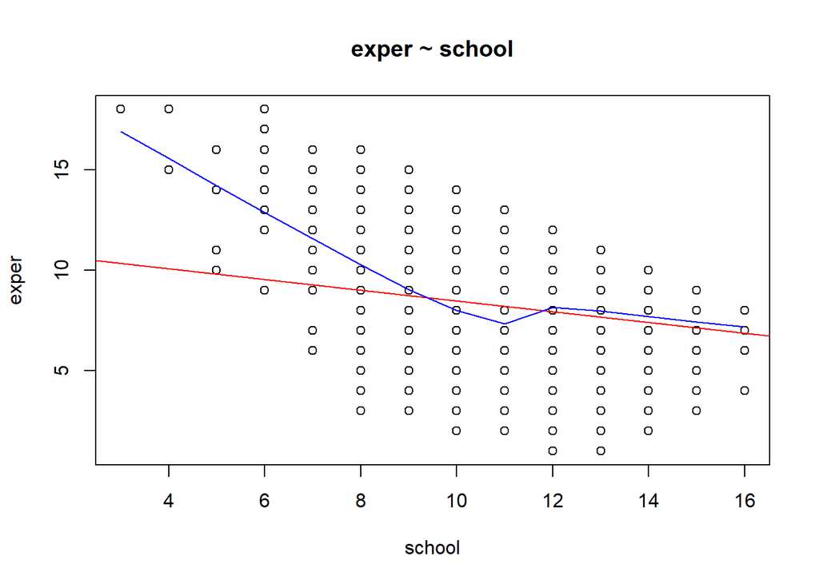

Tra school ed exper sembra esserci una correlazione inversa leggera, non di tipo propriamente lineare.

Per concludere, in quest’analisi la grande variabilità dei dati (in particolare la distribuzione “estrema” di wage) ha reso difficile trovare una chiara correlazione. Alcuni step successivi possibili potrebbero essere:

- la considerazione separata dei “casi normali” (stipendi medio-bassi) e dei casi estremi (stipendi molto alti), magari in due modelli distinti
- la considerazione di analisi prelinimari alternative, basate magari su tecniche di clustering

```r
summary(wages2)
```

```
##      exper        male         school           wage              region
##  Min.   : 1.000   0:1569   Min.   : 3.00   Min.   :  0.07656   Center:1164
##  1st Qu.: 7.000   1:1727   1st Qu.:11.00   1st Qu.:  3.62673   North :1105
##  Median : 8.000            Median :12.00   Median :  5.20578   South :1027
##  Mean   : 8.042            Mean   :11.63   Mean   :  5.81639
##  3rd Qu.: 9.000            3rd Qu.:12.00   3rd Qu.:  7.30723
##  Max.   :18.000            Max.   :16.00   Max.   :112.79193
##     logwage
##  Min.   :-2.570
##  1st Qu.: 1.288
##  Median : 1.650
##  Mean   : 1.589
##  3rd Qu.: 1.989
##  Max.   : 4.726
```